# figures_garcia_et_al

Felix Haidle

21 März 2024

# 1 Introduction

In this document the code for some of the figures in garcia et al is provided.

```r
# loading libraries
library(dplyr)
library(ggvenn)
library(BSgenome.Hsapiens.UCSC.hg38)
library(BSgenome.Mmusculus.UCSC.mm39)
library(GenomicRanges)
library(ggplot2)
library(ggsci)
library(ggrastr)
library(ggbeeswarm)
library(viridis)

# found in the utility folders
source("./utility/majiq_analysis_functions.R")
```

# 2 Figure 1

## 2.1 D

Regulated Splice Events in the HeLa datset. Regulation criteriea is explained in the methods part of the paper.

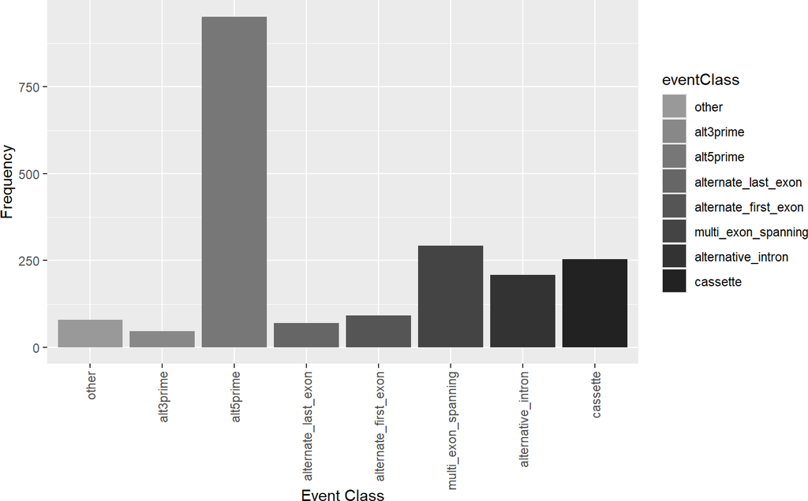

```r
# reading in modulize output
ASeventList <- loadTSVs("./data/modulize/HeLa")

# getting the amount of events for each type
eventFrequencies <- lapply(ASeventList, function(df){df$event_id %>% unique %>% length})

eventFrequencies <- eventFrequencies %>%
  as.data.frame()  %>%
  pivot_longer(., cols=everything(), names_to="ASevent", values_to = "Frequency")


# filtering out the signifcant events
significant_events <- identifySignificantEvents(ASeventList)

# amount of events filtered
regulatedEventFrequencies <- significant_events %>%
    dplyr::count(eventClass, name="Frequency")


# interesting event types, the other ones are put into the category "other"
eventsOfInterest <- c("cassette", "alternative_intron", "multi_exon_spanning",
                      "alternate_first_exon", "alternate_last_exon",
                      "alt5prime", "alt3prime", "other")

regulatedEventFrequencies <- regulatedEventFrequencies %>%
    add_row(
        regulatedEventFrequencies %>% filter(!eventClass %in% eventsOfInterest)  %>%
            summarise(eventClass="other", Frequency = sum(Frequency)) %>%
            select(eventClass, Frequency)
) %>% filter(., eventClass %in% eventsOfInterest) %>%
    mutate(eventClass=factor(eventClass, levels=rev(eventsOfInterest)))



custom_palette <- c("#999999", "#888888", "#777777", "#666666", "#555555", "#444444", "#333333", "#222222")

# building a bar plot from the data
regulatedEventFrequencies %>%
    mutate(eventClass=factor(eventClass)) %>%
    arrange(eventClass) %>%
    dplyr::rename(count="Frequency") %>%
    ggplot(aes(x=eventClass, y=count, fill=eventClass)) +
    geom_bar(stat="identity") +
    scale_fill_manual(values = custom_palette) +  # Using grayscale color palette
    labs(x = "Event Class", y = "Frequency") +
    theme(axis.text.x = element_text(angle = 90, vjust = 0.5, hjust=1))
```

## 2.2 F

Annotation status of the down and up regulated junctions.

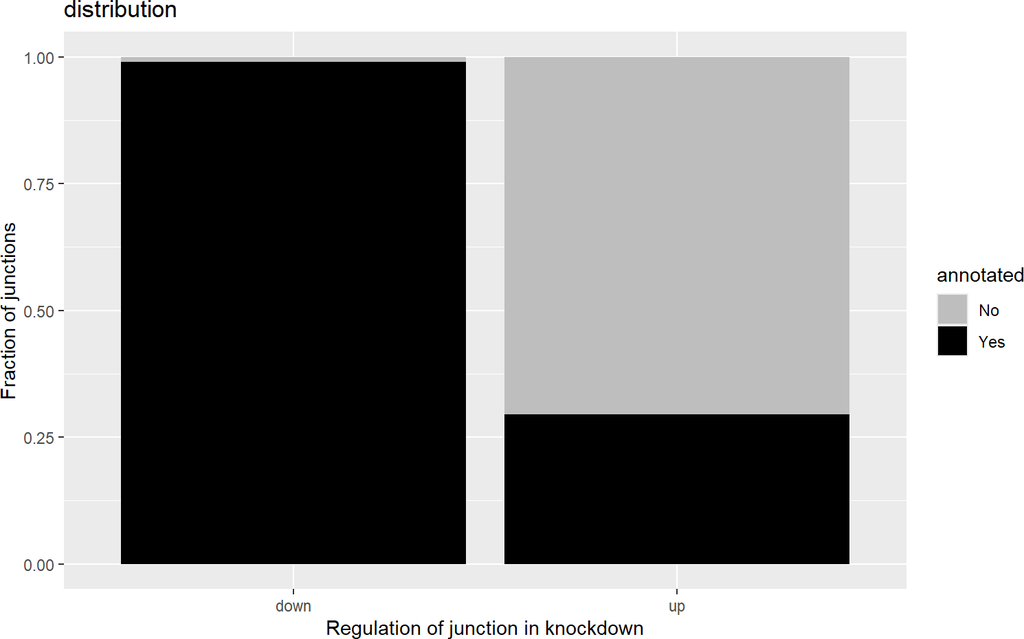

```r
# adding a colum to the data that indicates for each event wether it is regulated and if so if it is up or down regulated
modulize_regulated <- ASeventList[[3]] %>% select(event_id, junction_name, CT_median_psi, KD_median_psi, KD.CT_median_dpsi, denovo) %>%
  mutate(regulation = case_when((event_id %in% significant_events$event_id) & KD.CT_median_dpsi > 0 ~ "up",
                                  (event_id %in% significant_events$event_id) & KD.CT_median_dpsi < 0 ~ "down",
                                  ((!event_id %in% significant_events$event_id)) ~ "no")) %>%
    mutate(regulation=factor(regulation, levels=c("no", "down", "up")))

# renaming and grouping the regulated events by annotation status
current_df <- modulize_regulated  %>%
    dplyr::filter(regulation %in% c("up", "down")) %>%
    dplyr::rename(annotated = denovo) %>%
    mutate(annotated=ifelse(annotated == "True", "No", "Yes")) %>%
    group_by(regulation) %>%
    summarize(Yes=sum(annotated == "Yes") / n(),
              No=sum(annotated == "No") / n()) %>%
    pivot_longer(cols=2:3, names_to="annotated", values_to = "fraction")


# plotting the annotation/regulaiton status
plot <-ggplot(current_df, aes(x=regulation, y=fraction, fill=annotated)) +
    geom_col() +
    scale_fill_manual(values=c("No" = "grey", "Yes" = "black")) +
    labs(x="Regulation of junction in knockdown",
         y="Fraction of junctions") +
     theme(legend.position = "right") + ggtitle("distribution")
  plot
```

## 2.3 G

comparison of the max ent scan scores

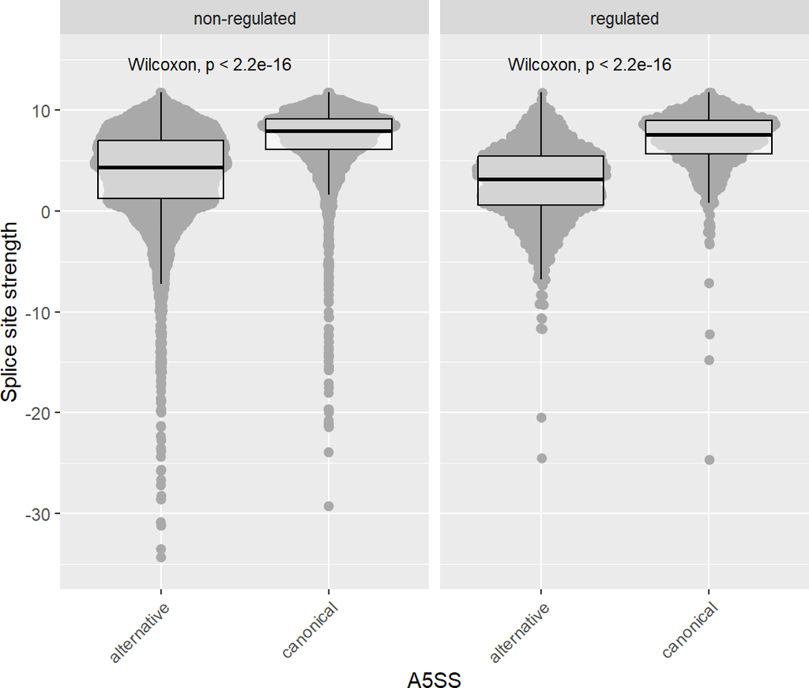

```r
# in case this code has already been run hte splice strength data frame is loaded otherwise it will be created and saved in the data folder
rds_path <- ("./data/rds_objects/HeLa_SSDF.rds")
if (!file.exists(rds_path)) {
  # read in regulated a5ss event granges objects
  HeLa_regulated <- readRDS("./data/rds_objects/HeLa_A5SSranges.rds")

  # read in not regulated a5ss event granges objects
  HeLa_not_regulated <- readRDS("./data/rds_objects/HeLa_nonRegA5SSranges.rds")

  A5SSranges <- HeLa_regulated
  nonRegulatedA5SSranges <- HeLa_not_regulated

  # procession of the granges objects
  # regulated
  canonicalSS <- endoapply(A5SSranges, function(gr){
  gr$exon_length <- width(gr)
  gr %>% plyranges::slice(which.min(KD.CT_median_dpsi))
  }) %>% unlist %>% resize(., 1, fix="end")

  alternativeSS <- endoapply(A5SSranges, function(gr){
  gr$exon_length <- width(gr)
  gr %>% plyranges::slice(which.max(KD.CT_median_dpsi))
  }) %>% unlist %>% resize(., 1, fix="end")

  # Non-regulated
  nonRegCanonicalSS <- endoapply(nonRegulatedA5SSranges, function(gr){
  gr$exon_length <- width(gr)
  gr %>% plyranges::slice(which.max(CT_median_psi))
  }) %>% unlist %>% resize(., 1, fix="end")

  nonRegAlternativeSS <- endoapply(nonRegulatedA5SSranges, function(gr){
  gr$exon_length <- width(gr)
  gr %>% plyranges::slice(which.min(CT_median_psi))
  }) %>% unlist %>% resize(., 1, fix="end")


  # function to calculate the splice site strength
  calc_splicesite_strength <- function(gr, set, A5SS){
  strengths <- gr %>%
        flank(., 6, start = FALSE) %>% promoters(., upstream = 3, downstream = 6) %>%
        getSeq(Hsapiens, .) %>%
        as.character() %>%
        VarCon::calculateMaxEntScanScore(., 5) %>%
        as.numeric()

  return(
        data.frame(
            set,
            A5SS,
            strength = strengths,
            event_id = gr$event_id,
            exon=gr$exon,
            splice_coordinate=start(gr)
        )
      )

    }

   # filtering the events
    eventsToKeep <- canonicalSS$event_id[canonicalSS$CT_median_psi > 0.5]
  canonicalSS <- canonicalSS %>% plyranges::filter(event_id %in% eventsToKeep)
  alternativeSS <- alternativeSS %>% plyranges::filter(event_id %in% eventsToKeep)

  eventsToKeep <- nonRegCanonicalSS$event_id[nonRegCanonicalSS$CT_median_psi > 0.5]
  nonRegCanonicalSS <- nonRegCanonicalSS %>% plyranges::filter(event_id %in% eventsToKeep)
  nonRegAlternativeSS <- nonRegAlternativeSS %>% plyranges::filter(event_id %in% eventsToKeep)


  # combining the scores in to one data frame
  spliceSiteStrengthDF <- rbind(
    calc_splicesite_strength(canonicalSS, "regulated", "canonical"),
    calc_splicesite_strength(alternativeSS, "regulated", "alternative"),
    calc_splicesite_strength(nonRegCanonicalSS, "non-regulated", "canonical"),
    calc_splicesite_strength(nonRegAlternativeSS, "non-regulated", "alternative")
    )
  saveRDS(spliceSiteStrengthDF,rds_path)
} else {
  # Load the dataframe from the RDS object
  spliceSiteStrengthDF <- readRDS(file = rds_path)
}


# plotting the max ent scores
p_splicesite_strength1 <- spliceSiteStrengthDF %>%
    ggplot(., aes(x=A5SS, y=strength)) +
        ggrastr::rasterise(geom_quasirandom(color="darkgrey"), dpi=300) +
        geom_boxplot(alpha=.5, outlier.size = -1, col="black") +
        facet_wrap(~set, ncol=2) +
        coord_cartesian(ylim=c(-35,15)) +
        ggpubr::stat_compare_means(label.y = 14, size=3) +
        labs(y="Splice site strength") +
        theme(aspect.ratio = 1.5/1,
              axis.text.x = element_text(angle=45, hjust = 1, vjust=1))
p_splicesite_strength1
```

# 3 Figure S4

## 3.1 RPE1

Regulated Splice Events in the RPE datset. Regulation criterea is explained in the methods part of the paper.

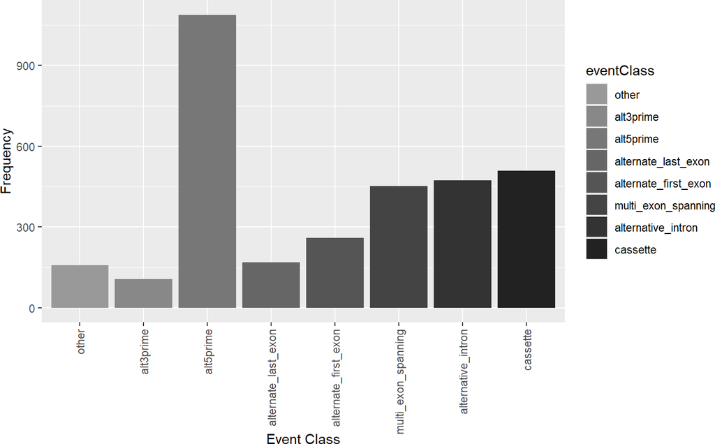

```r
# reading in modulize output
ASeventList <- loadTSVs("./data/modulize/RPE")

# getting the amount of events for each type
eventFrequencies <- lapply(ASeventList, function(df){df$event_id %>% unique %>% length})

eventFrequencies <- eventFrequencies %>%
  as.data.frame()  %>%
  pivot_longer(., cols=everything(), names_to="ASevent", values_to = "Frequency")

# filtering out the signifcant events
significant_events <- identifySignificantEvents(ASeventList)

# amount of events filtered
regulatedEventFrequencies <- significant_events %>%
    dplyr::count(eventClass, name="Frequency")

eventsOfInterest <- c("cassette", "alternative_intron", "multi_exon_spanning",
                      "alternate_first_exon", "alternate_last_exon",
                      "alt5prime", "alt3prime", "other")

# interesting event types, the other ones are put into the category "other"
regulatedEventFrequencies <- regulatedEventFrequencies %>%
    add_row(
        regulatedEventFrequencies %>% filter(!eventClass %in% eventsOfInterest)  %>%
            summarise(eventClass="other", Frequency = sum(Frequency)) %>%
            select(eventClass, Frequency)
) %>% filter(., eventClass %in% eventsOfInterest) %>%
    mutate(eventClass=factor(eventClass, levels=rev(eventsOfInterest)))


custom_palette <- c("#999999", "#888888", "#777777", "#666666", "#555555", "#444444", "#333333", "#222222")

# building a bar plot from the data
regulatedEventFrequencies %>%
    mutate(eventClass=factor(eventClass)) %>%
    arrange(eventClass) %>%
    dplyr::rename(count="Frequency") %>%
    ggplot(aes(x=eventClass, y=count, fill=eventClass)) +
    geom_bar(stat="identity") +
    scale_fill_manual(values = custom_palette) +  # Using grayscale color palette
    labs(x = "Event Class", y = "Frequency") +
    theme(axis.text.x = element_text(angle = 90, vjust = 0.5, hjust=1))
```

Annotation status of the down and up regulated junctions.

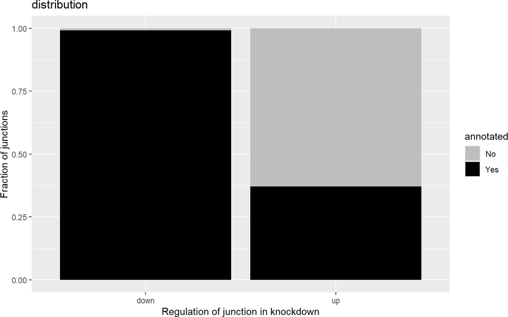

```r
#  adding a column to the data that indicates for each event wether it is regulated and if so if it is up or down regulated
modulize_regulated <- ASeventList[[3]] %>% select(event_id, junction_name, CT_median_psi, KO_median_psi, KO.CT_median_dpsi, denovo) %>%
  mutate(regulation = case_when((event_id %in% significant_events$event_id) & KO.CT_median_dpsi > 0 ~ "up",
                                  (event_id %in% significant_events$event_id) & KO.CT_median_dpsi < 0 ~ "down",
                                  ((!event_id %in% significant_events$event_id)) ~ "no")) %>%
    mutate(regulation=factor(regulation, levels=c("no", "down", "up")))


# renaming and grouping the regulated events by annotation status
current_df <- modulize_regulated  %>%
    dplyr::filter(regulation %in% c("up", "down")) %>%
    dplyr::rename(annotated = denovo) %>%
    mutate(annotated=ifelse(annotated == "True", "No", "Yes")) %>%
    group_by(regulation) %>%
    summarize(Yes=sum(annotated == "Yes") / n(),
              No=sum(annotated == "No") / n()) %>%
    pivot_longer(cols=2:3, names_to="annotated", values_to = "fraction")

# plotting the annotation/regulation status
plot <-ggplot(current_df, aes(x=regulation, y=fraction, fill=annotated)) +
    geom_col() +
    scale_fill_manual(values=c("No" = "grey", "Yes" = "black")) +
    labs(x="Regulation of junction in knockdown",
         y="Fraction of junctions") +
     theme(legend.position = "right") + ggtitle("distribution")
  plot
```

comparison of the max ent scan scores

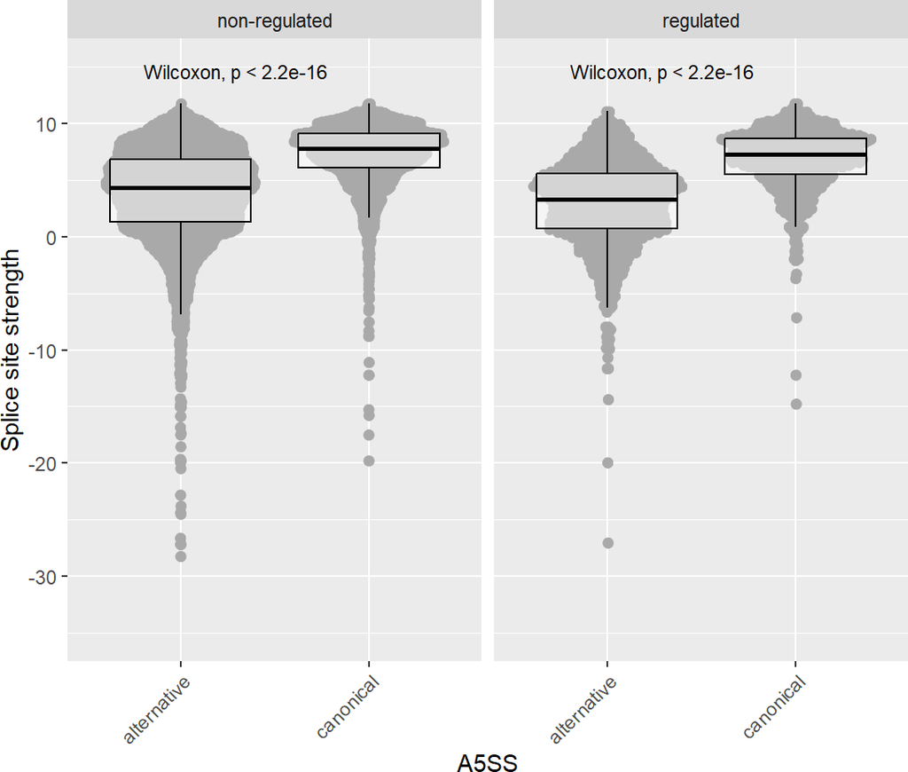

```r
# in case this code has already been run the splice strength data frame is loaded otherwise it will be created and saved in the data folder
rds_path <- ("./data/rds_objects/RPE_SSDF.rds")
if (!file.exists(rds_path)) {
  # read in regulated a5ss event granges objects
  RPE_regulated <- readRDS("./data/rds_objects/RPE_A5SSranges.rds")

  # read in not regulated a5ss event granges objects
  RPE_not_regulated <- readRDS("./data/rds_objects/RPE_nonRegA5SSranges.rds")

  A5SSranges <- RPE_regulated
  nonRegulatedA5SSranges <- RPE_not_regulated

  # procession of the granges objects
  # regulated
  canonicalSS <- endoapply(A5SSranges, function(gr){
  gr$exon_length <- width(gr)
  gr %>% plyranges::slice(which.min(KO.CT_median_dpsi))
  }) %>% unlist %>% resize(., 1, fix="end")

  alternativeSS <- endoapply(A5SSranges, function(gr){
  gr$exon_length <- width(gr)
  gr %>% plyranges::slice(which.max(KO.CT_median_dpsi))
  }) %>% unlist %>% resize(., 1, fix="end")

  # Non-regulated
  nonRegCanonicalSS <- endoapply(nonRegulatedA5SSranges, function(gr){
  gr$exon_length <- width(gr)
  gr %>% plyranges::slice(which.max(CT_median_psi))
  }) %>% unlist %>% resize(., 1, fix="end")

  nonRegAlternativeSS <- endoapply(nonRegulatedA5SSranges, function(gr){
  gr$exon_length <- width(gr)
  gr %>% plyranges::slice(which.min(CT_median_psi))
  }) %>% unlist %>% resize(., 1, fix="end")


  # function to calculate the splice site strength
  calc_splicesite_strength <- function(gr, set, A5SS){
  strengths <- gr %>%
        flank(., 6, start = FALSE) %>% promoters(., upstream = 3, downstream = 6) %>%
        getSeq(Hsapiens, .) %>%
        as.character() %>%
        VarCon::calculateMaxEntScanScore(., 5) %>%
        as.numeric()

  return(
        data.frame(
            set,
            A5SS,
            strength = strengths,
            event_id = gr$event_id,
            exon=gr$exon,
            splice_coordinate=start(gr)
        )
      )

    }

  # filtering the events
  eventsToKeep <- canonicalSS$event_id[canonicalSS$CT_median_psi > 0.5]
  canonicalSS <- canonicalSS %>% plyranges::filter(event_id %in% eventsToKeep)
  alternativeSS <- alternativeSS %>% plyranges::filter(event_id %in% eventsToKeep)

  eventsToKeep <- nonRegCanonicalSS$event_id[nonRegCanonicalSS$CT_median_psi > 0.5]
  nonRegCanonicalSS <- nonRegCanonicalSS %>% plyranges::filter(event_id %in% eventsToKeep)
  nonRegAlternativeSS <- nonRegAlternativeSS %>% plyranges::filter(event_id %in% eventsToKeep)

  # combining the scores in to one data frame
  spliceSiteStrengthDF <- rbind(
    calc_splicesite_strength(canonicalSS, "regulated", "canonical"),
    calc_splicesite_strength(alternativeSS, "regulated", "alternative"),
    calc_splicesite_strength(nonRegCanonicalSS, "non-regulated", "canonical"),
    calc_splicesite_strength(nonRegAlternativeSS, "non-regulated", "alternative")
    )
  saveRDS(spliceSiteStrengthDF,rds_path)
} else {
  # Load the dataframe from the RDS object
  spliceSiteStrengthDF <- readRDS(file = rds_path)
}

# plotting the max ent scores
p_splicesite_strength1 <- spliceSiteStrengthDF %>%
    ggplot(., aes(x=A5SS, y=strength)) +
        ggrastr::rasterise(geom_quasirandom(color="darkgrey"), dpi=300) +
        geom_boxplot(alpha=.5, outlier.size = -1, col="black") +
        facet_wrap(~set, ncol=2) +
        coord_cartesian(ylim=c(-35,15)) +
        ggpubr::stat_compare_means(label.y = 14, size=3) +
        labs(y="Splice site strength") +
        theme(aspect.ratio = 1.5/1,
              axis.text.x = element_text(angle=45, hjust = 1, vjust=1))
p_splicesite_strength1
```

## 3.2 HeLa & RPE1 Overlap

Comparison of regulated events between the HeLa and the RPE dataset. Diagram 1 shows the regulated 5’SS that are down regulated in the knockout Diagram 2 shows similarly these events but also taking into account wether the crypic splicesite is the same

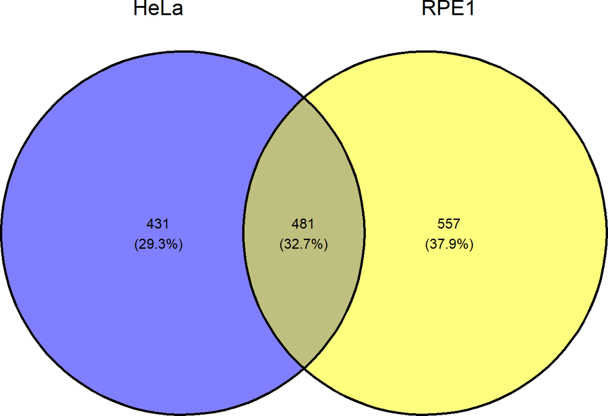

```r
# read in regulated a5ss events
HeLa <- readRDS("./data/rds_objects/HeLa_regulated_a5ss_events.rds")
RPE <- readRDS("./data/rds_objects/RPE_regulated_a5ss_events.rds")


# finding the canonic junctions
HeLa_match <- filter(HeLa,annotated=="annotated",regulation=="down")
RPE_match <- filter(RPE,annotated=="annotated",regulation=="down")

# getting splice coordinates
HeLa_canonic_5SS <- HeLa_match$junction_splice_position_changing
RPE_canonic_5SS <- RPE_match$junction_splice_position_changing

# pairs of splice coorddinate and the cryptiv coordinate
HeLa_canonic_and_alternative <- paste(HeLa_match$junction_splice_position_changing, HeLa_match$alternative_splice_site, sep = "-")
RPE_canonic_and_alternative <- paste(RPE_match$junction_splice_position_changing, RPE_match$alternative_splice_site, sep = "-")

# venn diagram of overlapping splice sites that are down regulated
venn_1 <- list(
  HeLa = HeLa_canonic_5SS,
  RPE1 = RPE_canonic_5SS
  )

ggvenn(venn_1)
```

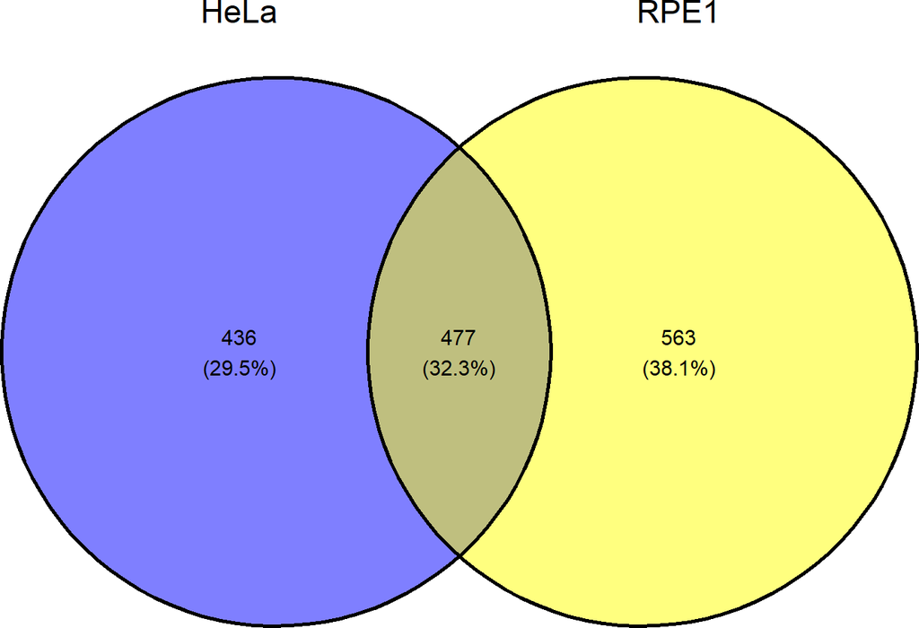

```r
# venn diagram of pairs were both the canonic and cryptic splice site were the same across both datasets
venn_2 <- list(
  HeLa = HeLa_canonic_and_alternative,
  RPE1 = RPE_canonic_and_alternative
  )
ggvenn(venn_2)
```

## 3.3 Mouse

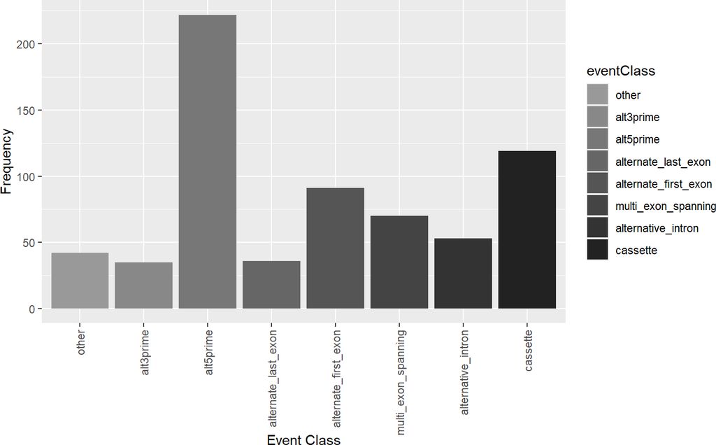

```r
# reading in modulize output
ASeventList <- loadTSVs("./data/modulize/GSE213633")

# getting the amount of events for each type
eventFrequencies <- lapply(ASeventList, function(df){df$event_id %>% unique %>% length})

eventFrequencies <- eventFrequencies %>%
  as.data.frame()  %>%
  pivot_longer(., cols=everything(), names_to="ASevent", values_to = "Frequency")

# filtering out the signifcant events
significant_events <- identifySignificantEvents(ASeventList)

# amount of events filtered
regulatedEventFrequencies <- significant_events %>%
    dplyr::count(eventClass, name="Frequency")

# interesting event types, the other ones are put into the category "other"
eventsOfInterest <- c("cassette", "alternative_intron", "multi_exon_spanning",
                      "alternate_first_exon", "alternate_last_exon",
                      "alt5prime", "alt3prime", "other")

regulatedEventFrequencies <- regulatedEventFrequencies %>%
    add_row(
        regulatedEventFrequencies %>% filter(!eventClass %in% eventsOfInterest)  %>%
            summarise(eventClass="other", Frequency = sum(Frequency)) %>%
            select(eventClass, Frequency)
) %>% filter(., eventClass %in% eventsOfInterest) %>%
    mutate(eventClass=factor(eventClass, levels=rev(eventsOfInterest)))

# building a bar plot from the data
custom_palette <- c("#999999", "#888888", "#777777", "#666666", "#555555", "#444444", "#333333", "#222222")

# building a bar plot from the data
regulatedEventFrequencies %>%
    mutate(eventClass=factor(eventClass)) %>%
    arrange(eventClass) %>%
    dplyr::rename(count="Frequency") %>%
    ggplot(aes(x=eventClass, y=count, fill=eventClass)) +
    geom_bar(stat="identity") +
    scale_fill_manual(values = custom_palette) +  # Using grayscale color palette
    labs(x = "Event Class", y = "Frequency") +
    theme(axis.text.x = element_text(angle = 90, vjust = 0.5, hjust=1))
```

Annotation status of the down and up regulated junctions.

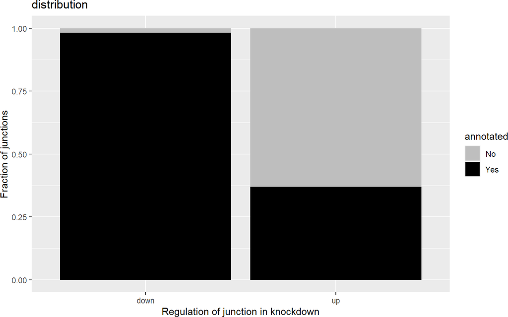

```r
# adding a colum to the data that indicates for each event wether it is regulated and if so if it is up or down regulated
modulize_regulated <- ASeventList[[3]] %>% select(event_id, junction_name, WT_median_psi, KO_median_psi, KO.WT_median_dpsi, denovo) %>%
  mutate(regulation = case_when((event_id %in% significant_events$event_id) & KO.WT_median_dpsi > 0 ~ "up",
                                  (event_id %in% significant_events$event_id) & KO.WT_median_dpsi < 0 ~ "down",
                                  ((!event_id %in% significant_events$event_id)) ~ "no")) %>%
    mutate(regulation=factor(regulation, levels=c("no", "down", "up")))


# renaming and grouping the regulated events by annotation status
current_df <- modulize_regulated  %>%
    dplyr::filter(regulation %in% c("up", "down")) %>%
    dplyr::rename(annotated = denovo) %>%
    mutate(annotated=ifelse(annotated == "True", "No", "Yes")) %>%
    group_by(regulation) %>%
    summarize(Yes=sum(annotated == "Yes") / n(),
              No=sum(annotated == "No") / n()) %>%
    pivot_longer(cols=2:3, names_to="annotated", values_to = "fraction")

# plotting the annotation/regulaiton status
plot <-ggplot(current_df, aes(x=regulation, y=fraction, fill=annotated)) +
    geom_col() +
    scale_fill_manual(values=c("No" = "grey", "Yes" = "black")) +
    labs(x="Regulation of junction in knockdown",
         y="Fraction of junctions") +
     theme(legend.position = "right") + ggtitle("distribution")
  plot
```

comparison of the max ent scan scores

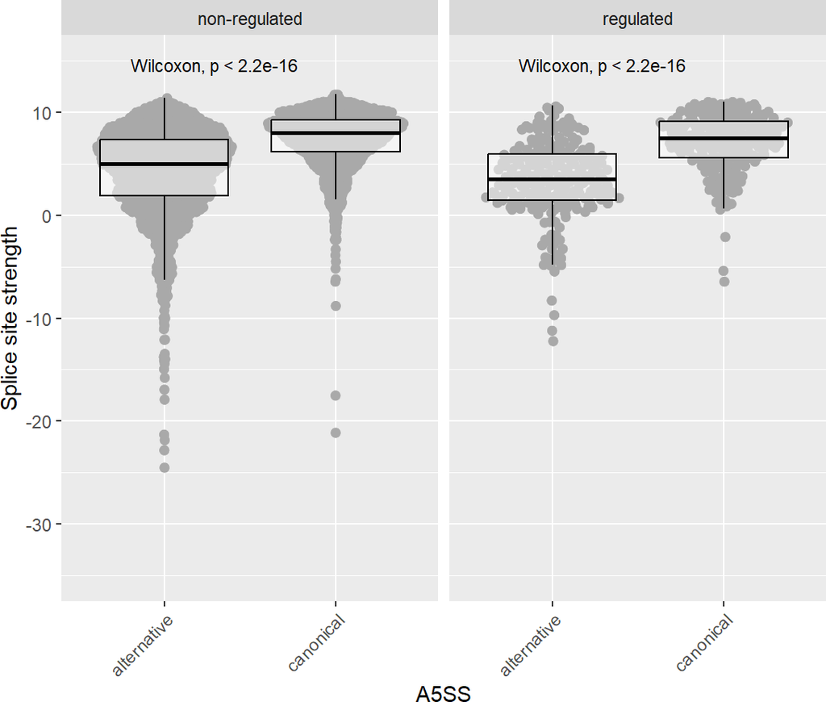

```r
# in case this code has already been run hte splice strength data frame is loaded otherwise it will be created and saved in the data folder
rds_path <- ("./data/rds_objects/GSE213633_SSDF.rds")

if (!file.exists(rds_path)) {
  # read in regulated a5ss event granges objects
  GSE213633_regulated <- readRDS("./data/rds_objects/GSE213633_A5SSranges.rds")

  # read in not regulated a5ss event granges objects
  GSE213633_not_regulated <- readRDS("./data/rds_objects/GSE213633_nonRegA5SSranges.rds")

  A5SSranges <- GSE213633_regulated
  nonRegulatedA5SSranges <- GSE213633_not_regulated

  # procession of the granges objects
  # regulated
  canonicalSS <- endoapply(A5SSranges, function(gr){
  gr$exon_length <- width(gr)
  gr %>% plyranges::slice(which.min(KO.WT_median_dpsi))
  }) %>% unlist %>% resize(., 1, fix="end")

  alternativeSS <- endoapply(A5SSranges, function(gr){
  gr$exon_length <- width(gr)
  gr %>% plyranges::slice(which.max(KO.WT_median_dpsi))
  }) %>% unlist %>% resize(., 1, fix="end")

  # Non-regulated
  nonRegCanonicalSS <- endoapply(nonRegulatedA5SSranges, function(gr){
  gr$exon_length <- width(gr)
  gr %>% plyranges::slice(which.max(WT_median_psi))
  }) %>% unlist %>% resize(., 1, fix="end")

  nonRegAlternativeSS <- endoapply(nonRegulatedA5SSranges, function(gr){
  gr$exon_length <- width(gr)
  gr %>% plyranges::slice(which.min(WT_median_psi))
  }) %>% unlist %>% resize(., 1, fix="end")


  # function to calculate the splice site strength
  calc_splicesite_strength <- function(gr, set, A5SS){
  strengths <- gr %>%
        flank(., 6, start = FALSE) %>% promoters(., upstream = 3, downstream = 6) %>%
        getSeq(Mmusculus, .) %>%
        as.character() %>%
        VarCon::calculateMaxEntScanScore(., 5) %>%
        as.numeric()

  return(
        data.frame(
            set,
            A5SS,
            strength = strengths,
            event_id = gr$event_id,
            exon=gr$exon,
            splice_coordinate=start(gr)
        )
      )

    }

  # filtering the events
  eventsToKeep <- canonicalSS$event_id[canonicalSS$WT_median_psi > 0.5]
  canonicalSS <- canonicalSS %>% plyranges::filter(event_id %in% eventsToKeep)
  alternativeSS <- alternativeSS %>% plyranges::filter(event_id %in% eventsToKeep)

  eventsToKeep <- nonRegCanonicalSS$event_id[nonRegCanonicalSS$WT_median_psi > 0.5]
  nonRegCanonicalSS <- nonRegCanonicalSS %>% plyranges::filter(event_id %in% eventsToKeep)
  nonRegAlternativeSS <- nonRegAlternativeSS %>% plyranges::filter(event_id %in% eventsToKeep)


  spliceSiteStrengthDF <- rbind(
    calc_splicesite_strength(canonicalSS, "regulated", "canonical"),
    calc_splicesite_strength(alternativeSS, "regulated", "alternative"),
    calc_splicesite_strength(nonRegCanonicalSS, "non-regulated", "canonical"),
    calc_splicesite_strength(nonRegAlternativeSS, "non-regulated", "alternative")
    )
  saveRDS(spliceSiteStrengthDF,rds_path)
} else {
  # Load the dataframe from the RDS object
  spliceSiteStrengthDF <- readRDS(file = rds_path)
}

# plotting the max ent scores
p_splicesite_strength1 <- spliceSiteStrengthDF %>%
    ggplot(., aes(x=A5SS, y=strength)) +
        ggrastr::rasterise(geom_quasirandom(color="darkgrey"), dpi=300) +
        geom_boxplot(alpha=.5, outlier.size = -1, col="black") +
        facet_wrap(~set, ncol=2) +
        coord_cartesian(ylim=c(-35,15)) +
        ggpubr::stat_compare_means(label.y = 14, size=3) +
        labs(y="Splice site strength") +
        theme(aspect.ratio = 1.5/1,
              axis.text.x = element_text(angle=45, hjust = 1, vjust=1))
p_splicesite_strength1
```